# 4 Blood: Differential Gene expression analysis

Ana BVA

28 novembre 2020

## Introduction

**Aim:** To perform differential expression analysis in COPD experiments, contransting COPD vs Control group

We previously had run the following scripts:

- 1: Dowload RAW data `/1-Blood-download_raw-data.RMD`
- 2: Normalizing data `/2-Blood-normalizing-data.RMD`
- 3: Curating data `/3-Blood-curatig-data.RMD`

## Input

This script needs the following files, which were obtained by step 3 `/3-Blood-curatig-data.RMD`:

**Table:** GSE summary `Blood_2020-11-25_Step3_Summary.csv`  
**Data 2:** ExpressionSet objects with normalized and curated data `Blood_2020-11-25_Step3_LungTissue-CURATED.RDS`

## Setup

```bash
ssh -X aaltamirano@dna.lavis.unam.mx
qrsh
cd /home/ana/DataDNA/R-projects/Meta-analysis_COPD/Blood/output_data/.out
 module load r/4.0.1

nohup R -e "rmarkdown::render(here::here('Blood/vignettes/3-Blood-curatig-data.RMD'))" > 3-Blood-curatig-data.RMD.out &
```

The script can be found in: /home/ana/DataDNA/R-projects/Meta-analysis_COPD/Blood/vignettes. And the directories were set using `R/setup.R` (e.i. DATA, OUPUT, DOWNLOAD) as a small functions that will paste the names into complete paths.

```r
knitr::opts_knit$set(root.dir = here::here())
source(here::here("Blood/R/setup.R"))
```

And this analysis is run in: /home/ana/DataDNA/R-projects/Meta-analysis_COPD

### Libraries

```r
library(tidyverse)
library(knitr)
library(DESeq2)
library(limma)
library(oligo)
library(vsn)
```

### Experiments

```r
gse_table <- read.csv(OUTPUT("2020-11-25_Step3_Summary.csv"), row.names = 1)
kable(gse_table, caption = "GSE Blood information") %>%
  kableExtra::scroll_box(width = "100%", height = "100px")
```

GSE Blood information

|  | CONTROL | COPD | COUNTRY | SUBMISSION_DATE | PLATFORM | NUM_GENES | AGE_MEAN | AGE_MEDIAN | AGE_RANGE | SEX_F | SEX_M | SMOKING_STATUS | PACKYEAR |
| --- | --- | --- | --- | --- | --- | --- | --- | --- | --- | --- | --- | --- | --- |
| GSE112811 | 22 | 20 | United Kingdom | Apr 06 2018 | GPL570 | 22881 | NA | NA | NA | NA | NA | NA | NA |
| GSE56766 | 29 | 49 | USA | Apr 14 2014 | GPL570 | 22881 | NA | NA | NA | NA | NA | NA, NON-SMOKER, SMOKER, 139, 5, 62 | NA |
| GSE42057 | 42 | 94 | USA | Nov 06 2012 | GPL570 | 22881 | 63.09853 | 62.75 | 45-79.6 | 1 | 1 | NA | NA |
| GSE94916 | NA | 6 | Germany | Feb 15 2017 | GPL20844 | 34730 | NA | NA | NA | NA | NA | NA | NA |
| GSE76705 | 86 | 143 | USA | Jan 11 2016 | GPL570 | 23521 | 63.43668 | 64.00 | 40-75 | 1 | 0 | NA | 35 |

## Local functions

### **DE**: Differential expression analysis

Using this funtion, we get a table with differential expression gene results using `limma` package for fitting a linear model to get genes deferentially expressed between a “Control” and a “COPD” group.

**Input:** GSE ID, optional: *colCOPD* is the column name in which the information of disease status can be found, *coeff* will show results of contrast with coeffitient found in possiton 2  
**Output:** Table of differential expression results with all genes

```r
DE <- function(ExpressionSet,colCOPD="DISEASE",coeff= "DISEASECOPD"){
     # it creates the design matrix and performs limma
     fit <- lmFit(ExpressionSet, model.matrix(as.formula(paste("~ 1 +", colCOPD)),
                                              data = pData(ExpressionSet)))
     # eBayes in lmFit model
     ebf <- eBayes(fit)
     print(colnames(coef(fit)))
     # It gets the genes with the p-values
     volcanoplot(ebf,coef = coeff,highlight=20, pch=20)
     res <- topTable(ebf, number = Inf, p.value = 1, coef = coeff,confint=T)
     # It formats in a tibble
     res <- as_tibble(res,rownames="rownames")
}
```

For microarray experiments, all the following steps are the same, so we will wrap the following code into one function.

**Input:** Position of the GSE id inside of `geo` list (e.i. 1,2..)  
**Output:** Table with DE results and a `.csv` genes

```r
save_DE <- function(i){

g <- geo[[i]]
message("plotting data")
boxplot(g)
hist(g)

# DE using a local function. DISEASE is a column with disease status information
message("DE analysis")
de <- DE(g,colCOPD = "DISEASE")

# renaming colnames with the GSE id
message("Renaming colnames with GSE id")
colnames(de) <- str_c(colnames(de),"_",names(geo)[i])
colnames(de)

# saving the results in a csv
message("Saving data into csv")
write_csv(de,file= here::here(str_c("Blood/output_data/DE/",TODAY,"_Blood_Step4_TableGenes_",i,"_",names(geo[i]),".csv")))

# saving the results to later combine all the information
 return(de)
}
```

## Analysis

### DATA

```r
geo <- readRDS(OUTPUT("2020-11-25_Step3_LungTissue-CURATED.RDS"))
names(geo) <- gsub(".GSE.*","",names(geo))
names(geo)
```

```
## [1] "GSE112811" "GSE56766"  "GSE42057"  "GSE94916"  "GSE76705"
```

## Differential expression analysis

Using `DE()` function (described above), we performed a lineal regression model to calculate the logarithm fold change of all genes between a “Control” and a “COPD” group. We also rename colnames adding the GSE ID at the end and finally, we save the output in a `.CSV` file.

### GSE112811

```r
i <- 1
de1 <- save_DE(i)
```

```
## plotting data
```

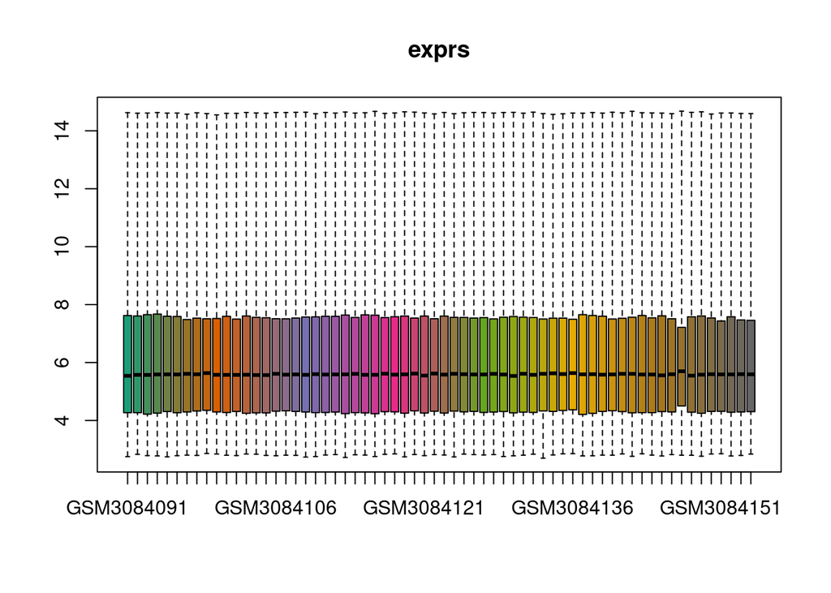

```
## DE analysis
```

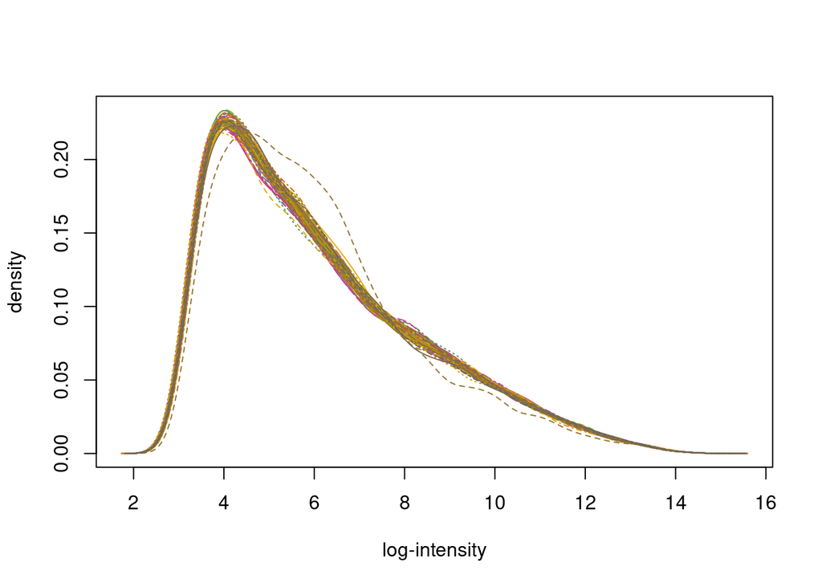

```
## [1] "(Intercept)"             "DISEASECOPD"
## [3] "DISEASEpost-LPS-CONTROL"
```

```
## Renaming colnames with GSE id
```

```
## Saving data into csv
```

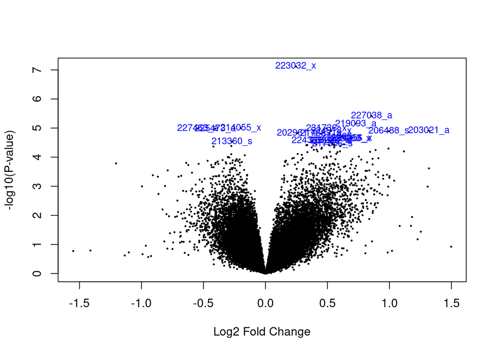

### GSE56766

```r
i <- 2
de1 <- save_DE(i)
```

```
## plotting data
```

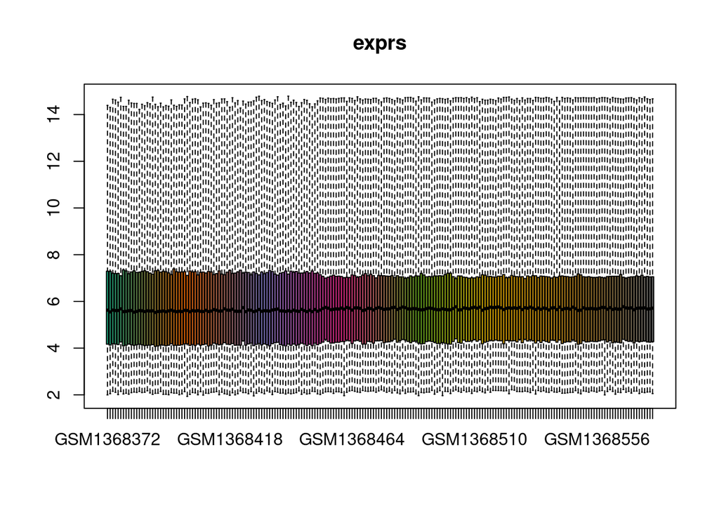

```
## DE analysis
```

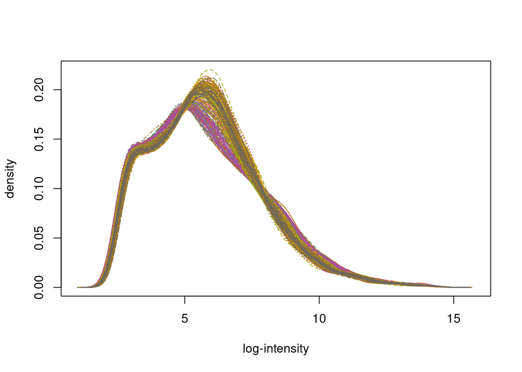

```
## [1] "(Intercept)"               "DISEASECOPD"
## [3] "DISEASEScreen-fail"        "DISEASEstimulated-SAMPLES"
```

```
## Renaming colnames with GSE id
```

```
## Saving data into csv
```

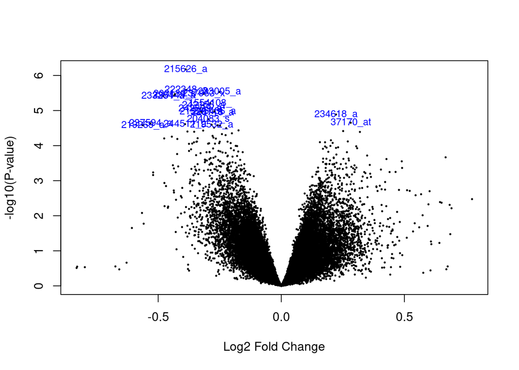

### GSE42057

```r
i <- 3
de3 <- save_DE(i)
```

```
## plotting data
```

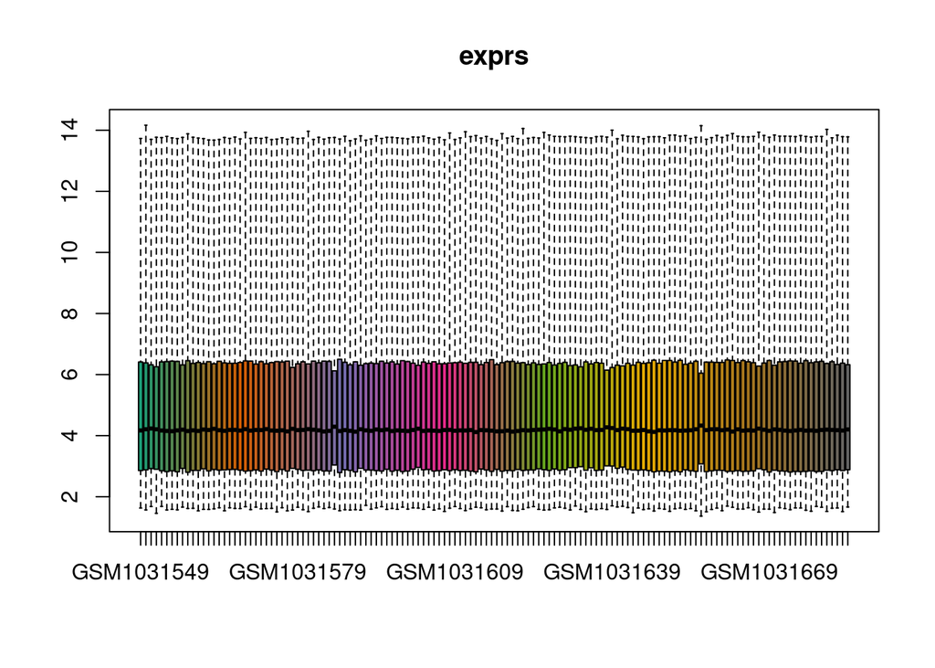

```
## DE analysis
```

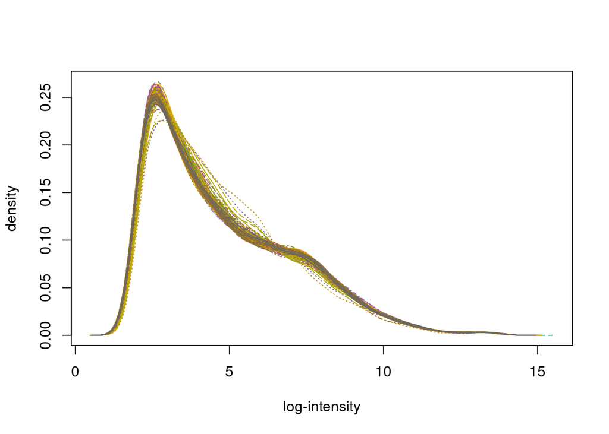

```
## [1] "(Intercept)" "DISEASECOPD"
```

```
## Renaming colnames with GSE id
```

```
## Saving data into csv
```

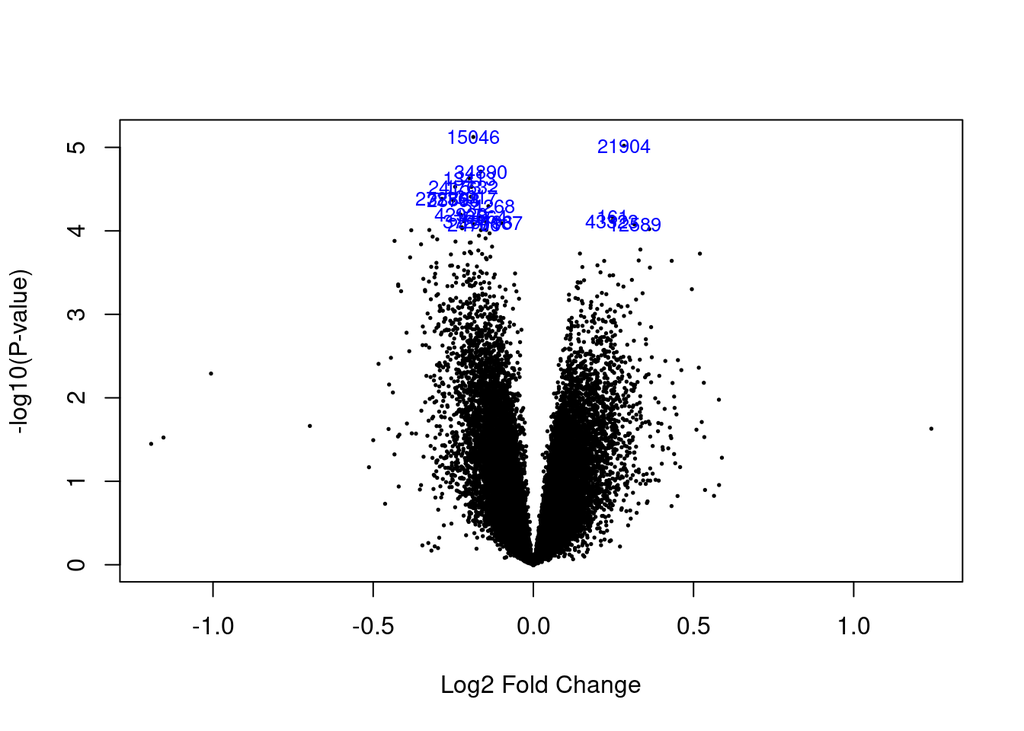

### GSE94916

```r
i <- 4
de4 <- save_DE(i)
```

```
## plotting data
```

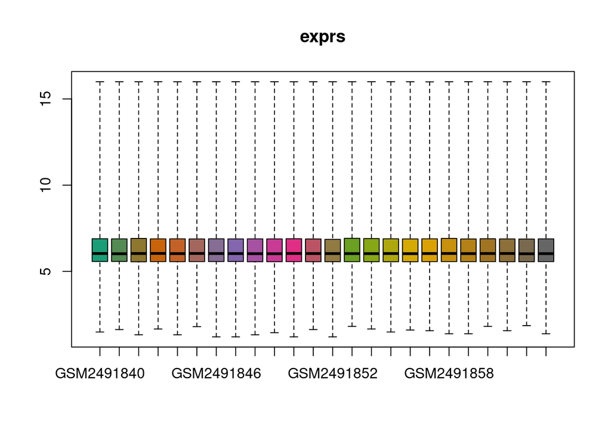

```
## DE analysis
```

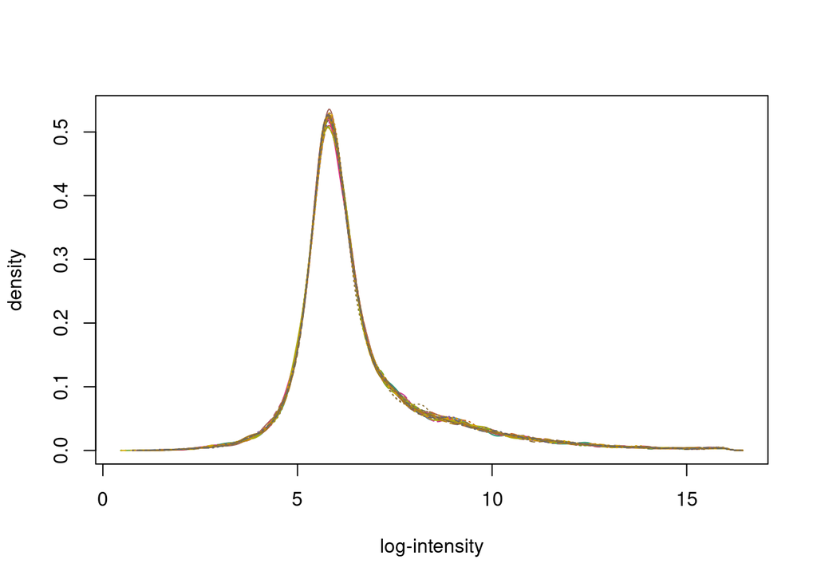

```
## [1] "(Intercept)"      "DISEASECOPD"      "DISEASEMalaria"   "DISEASEPneumonia"
```

```
## Renaming colnames with GSE id
```

```
## Saving data into csv
```

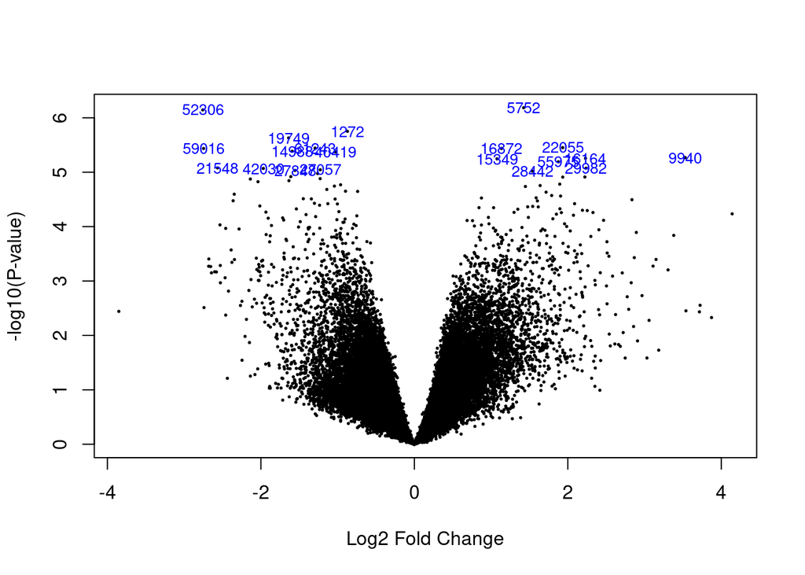

### GSE76705

```r
i <- 5
de4 <- save_DE(i)
```

```
## plotting data
```

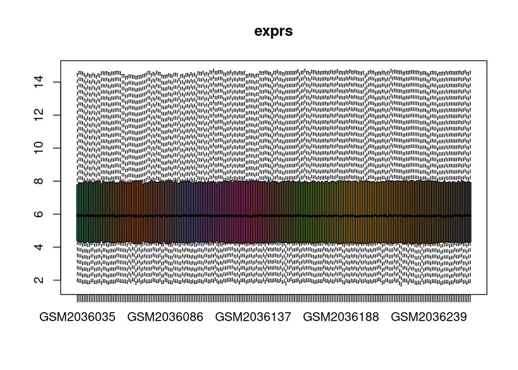

```
## DE analysis
```

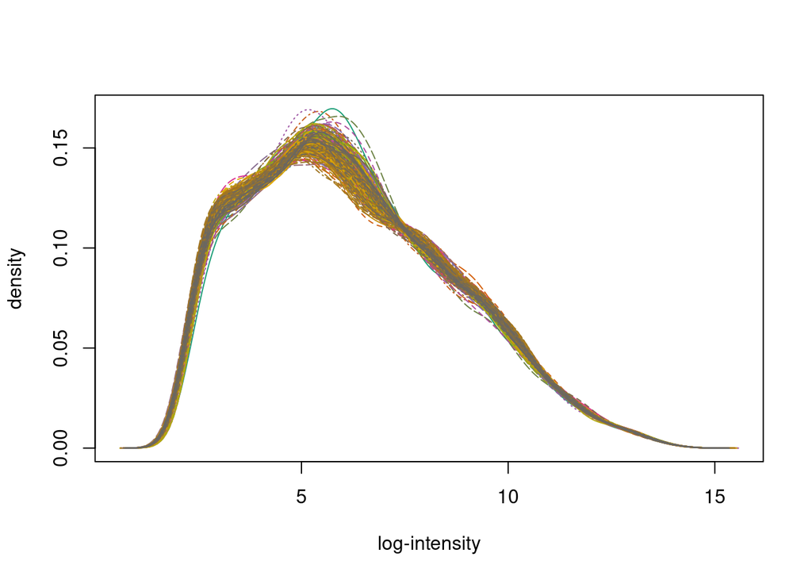

```
## [1] "(Intercept)" "DISEASECOPD"
```

```
## Renaming colnames with GSE id
```

```
## Saving data into csv
```

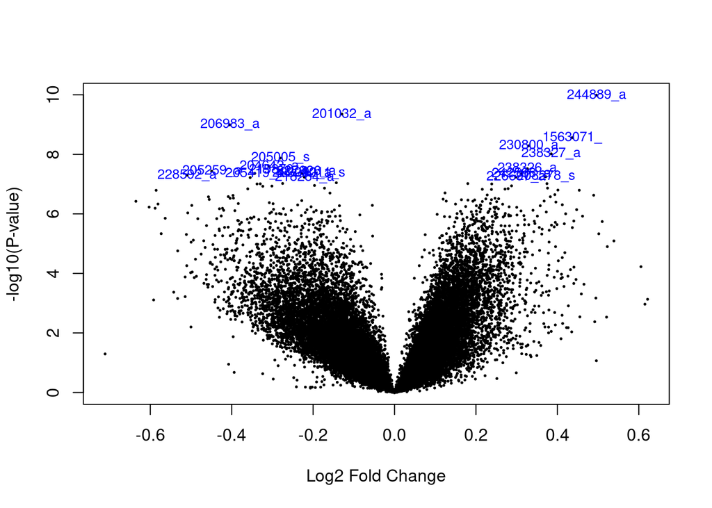

## Output

This script produces the following data, and can be found in /home/ana/DataDNA/R-projects/Meta-analysis_COPD

**Tables with DE results:** Tables with log fold change and p-values calculated per experiment and saved in `csv` files